# A1.1 611107

**A1.1 Aprendizaje estadístico-automático**

**1.** En el siguiente bloque de código se importa el archivo *"Obesidad.csv"* al ambiente de trabajo con la función **read_csv()** y se imprimen las primeras 10 filas para comprobar que la importación fue exitosa con el comando **head(10)**.

```python
import pandas as pd

data = pd.read_csv("A1.1 Obesidad.csv")

print(data.head(10))
```

```
     Sexo  Edad  Estatura  Peso FamiliarConSobrepeso ComeMuchasCalorias  \
0  Female  21.0      1.62  64.0                  yes                 no
1  Female  21.0      1.52  56.0                  yes                 no
2    Male  23.0      1.80  77.0                  yes                 no
3    Male  27.0      1.80  87.0                   no                 no
4    Male  22.0      1.78  89.8                   no                 no
5    Male  29.0      1.62  53.0                   no                yes
6  Female  23.0      1.50  55.0                  yes                yes
7    Male  22.0      1.64  53.0                   no                 no
8    Male  24.0      1.78  64.0                  yes                yes
9    Male  22.0      1.72  68.0                  yes                yes

   ComeVegetales Fumador  ConsumoDeAgua      NivelDeObesidad
0            2.0      no            2.0        Normal_Weight
1            3.0     yes            3.0        Normal_Weight
2            2.0      no            2.0        Normal_Weight
3            3.0      no            2.0   Overweight_Level_I
4            2.0      no            2.0  Overweight_Level_II
5            2.0      no            2.0        Normal_Weight
6            3.0      no            2.0        Normal_Weight
7            2.0      no            2.0        Normal_Weight
8            3.0      no            2.0        Normal_Weight
9            2.0      no            2.0        Normal_Weight
```

**2.** Otra variable que hubiera decidido medir si formara parte del grupo de investigación sería:

**CIRCUNFERENCIA DE LA CINTURA**, la cual es una variable **CUANTITATIVA**

Ya que, investigando, este factor también se considera como indicador para detectar la obesidad. De acuerdo con la Secretaría de Salud de México (2016), "el riesgo aumenta si la circunferencia de cintura mide más de 80 centímetros en mujeres y más de 90 centímetros en el caso de los hombres". Por lo tanto, parece interesante ver la relación entre este factor y los demás presentados en la base de datos.

Otra variable podría ser:

**HORAS A LA SEMANA DEDICADAS A HACER EJERCICIO**, la cual es una variable **CUANTITATIVA** que podría indicar si la actividad física tiene algún impacto en el nivel de obesidad.

**3.** Si elaborara un estudio de inferencia, utilizaría **NivelDeObesidad** como salida, ya que me interesa conocer cómo las demás variables influyen en que una persona tenga cierto nivel de obesidad. **NivelDeObesidad** es una variable **CUALITATIVA**.

En el siguiente bloque de código se hace uso de la función **value_counts()** para calcular la cantidad de personas que pertenecen a cada categoría.

```python
pd.value_counts(data.NivelDeObesidad)
```

```
Obesity_Type_I         351
Obesity_Type_III       324
Obesity_Type_II        297
Overweight_Level_I     290
Overweight_Level_II    290
Normal_Weight          287
Insufficient_Weight    272
Name: NivelDeObesidad, dtype: int64
```

**4.** En el siguiente bloque de código se muestra una gráfica para la población femenina. Para obtener esta parte de la población, se aplica la condición *== "Female"* sobre la columna *Sexo* de los datos. Es decir: `data.Sexo == "Female"`

Posteriormente, para el **eje Y** se utiliza el nivel de obesidad que se seleccionó en el punto anterior, mientras que en el **eje X** se utiliza el peso, una de las variables cuantitativas de la base de datos. Como sólamente me interesa la población femenina, es necesario utilizar el código descrito anteriormente sobre las dos columnas que se van a utilizar (*nivel de obesidad* y *peso*).

Por último, se utilizó la librería plt para graficar. La función `plt.figure` ayuda a definir el tamaño del gráfico, y la función `plt.scatter` grafica los datos indicados.

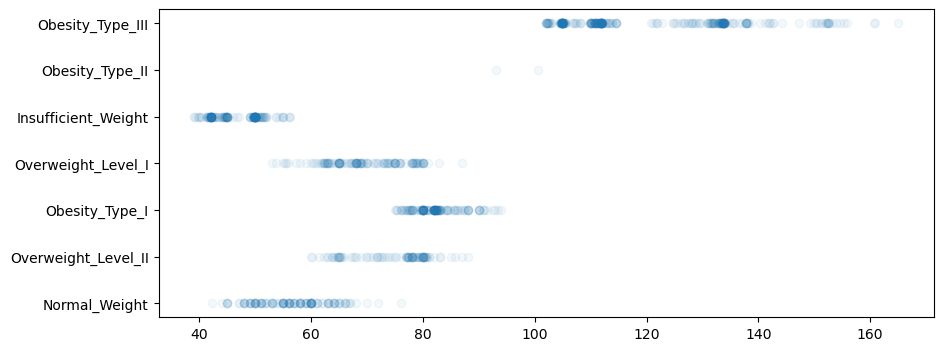

```python
%matplotlib inline

import matplotlib.pyplot as plt

# Definir "x" y "y", teniendo en cuenta sólo a la población FEMENINA
data_x = data.Peso[data.Sexo == "Female"]
data_y = data.NivelDeObesidad[data.Sexo == "Female"]

# Graficar datos
plt.figure(figsize=(10, 4))
plt.scatter(x = data_x, y = data_y, alpha = 0.05)
plt.show()
```

**Referencias**

- Secretaría de Salud (2016, 14 de julio). *Indicadores de sobrepeso y obesidad*. Gobierno de México. Consultado el 8 de agosto de 2023. https://www.gob.mx/salud/articulos/indicadores-de-sobrepeso-y-obesidad?idiom=es.

**Firma de Honor**: "Doy mi palabra que he realizado esta actividad con integridad académica" - Karen Garza Treviño, 611107